# FINAL_A2_P2_LangASD_predictions_instructions

### Exercise 3) Assessing the single child

Let’s get to business. This new kiddo - Bernie - has entered your clinic. This child has to be assessed according to his group’s average and his expected development.

Bernie is one of the six kids in the test dataset, so make sure to extract that child alone for the following analysis.

You want to evaluate:

- how does the child fare in ChildMLU compared to the average TD child at each visit? Define the distance in terms of absolute difference between this Child and the average TD.

```r
# SIGRID

########################## BERNIE IS BETTER THAN TD ###################################

#Getting the mean for each TD child pr visit
mean_td <- data %>%
  filter(Diagnosis == "TD") %>%
  group_by(Visit) %>%
  summarise(mean_CHI_MLU = mean(CHI_MLU))

#Getting the mean for each ASD child pr visit for the plot
mean_asd <- data %>%
  filter(Diagnosis == "ASD") %>%
  group_by(Visit) %>%
  summarise(mean_CHI_MLU = mean(CHI_MLU))

# Extracting Bernie
bernie <- data_test %>%
  filter(Subject == 2) %>%
  mutate(
    Absolute_dif = abs(mean_td$mean_CHI_MLU - CHI_MLU),
    mean_td = (mean_td$mean_CHI_MLU),
    mean_asd = (mean_asd$mean_CHI_MLU)) %>%
  select(
    Subject, Diagnosis, Visit, CHI_MLU, mean_td, mean_asd, Age, Absolute_dif)

bernie
```

```
##   Subject Diagnosis Visit  CHI_MLU  mean_td mean_asd   Age Absolute_dif
## 1       2       ASD     1 1.984456 1.310174 1.304476 27.80    0.6742815
## 2       2       ASD     2 2.544444 1.778062 1.443683 33.33    0.7663823
## 3       2       ASD     3 3.353191 2.229037 1.799177 36.23    1.1241544
## 4       2       ASD     4 3.183099 2.734681 1.815197 40.03    0.4484175
## 5       2       ASD     5 3.173252 2.969893 1.598512 45.47    0.2033593
## 6       2       ASD     6 3.448413 2.927875 1.940044 49.30    0.5205373
```

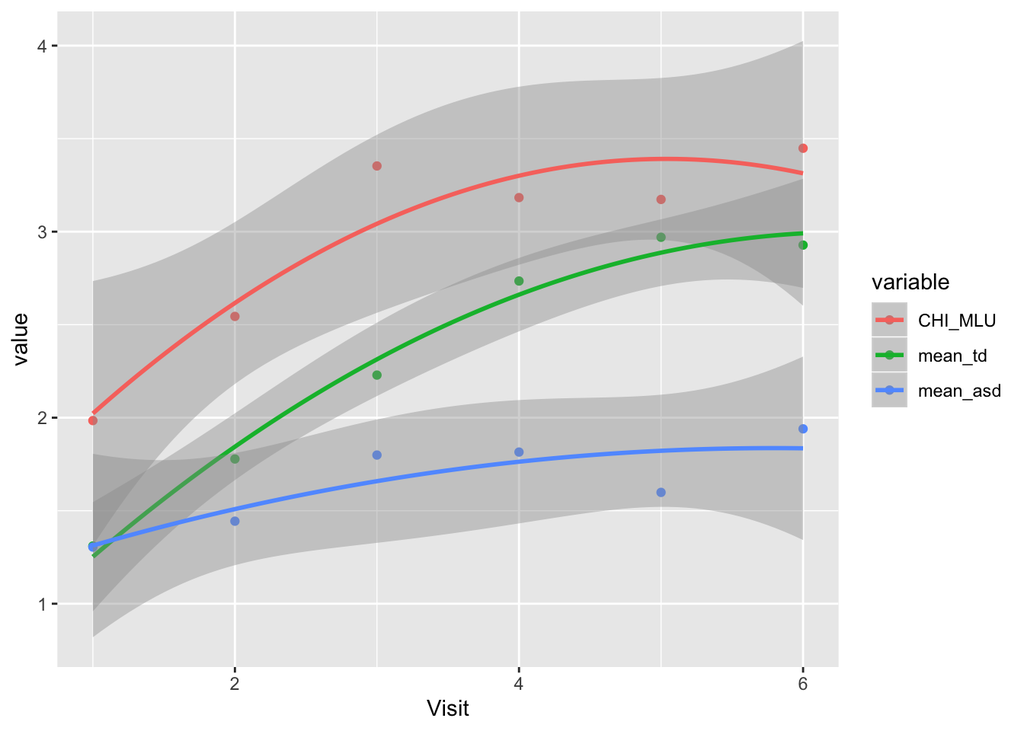

```r
#Plotting
bernie %>%
  select(
    Subject, Diagnosis, Visit, CHI_MLU, mean_td, mean_asd, Age) %>%
  melt(id.vars = c("Subject","Visit","Age","Diagnosis")) %>%
  ggplot()+
  aes(x = Visit, y = value, color = variable)+
  geom_point()+
  geom_smooth(method = lm, formula = y ~ x + I(x^2))
```

- how does the child fare compared to the model predictions at Visit 6? Is the child below or above expectations? (tip: use the predict() function on Bernie’s data only and compare the prediction with the actual performance of the child)

```r
# GUSTAV

# creating model
m1 <- lmer(CHI_MLU ~ Diagnosis*Visit+(Visit|Subject)+I(Visit^2), data)

bernie <- bernie %>%
  mutate(
    predicted = predict(m1, bernie, allow.new.levels = T)
  )

#according to the model, Bernie's predicted MLU at visit 6 is 1.5988

bernie %>%
  filter(Visit == 6) %>%
  select(Visit, CHI_MLU, predicted) %>%
  mutate(
    dif = CHI_MLU - predicted
  )
```

```
##   Visit  CHI_MLU predicted      dif
## 1     6 3.448413  1.598815 1.849597
```

```r
# Bernie is better
```

### OPTIONAL: Exercise 4) Model Selection via Information Criteria

Another way to reduce the bad surprises when testing a model on new data is to pay close attention to the relative information criteria between the models you are comparing. Let’s learn how to do that!

Re-create a selection of possible models explaining ChildMLU (the ones you tested for exercise 2, but now trained on the full dataset and not cross-validated).

Then try to find the best possible predictive model of ChildMLU, that is, the one that produces the lowest information criterion.

- Bonus question for the optional exercise: are information criteria correlated with cross-validated RMSE? That is, if you take AIC for Model 1, Model 2 and Model 3, do they co-vary with their cross-validated RMSE?

### OPTIONAL: Exercise 5): Using Lasso for model selection

Welcome to the last secret exercise. If you have already solved the previous exercises, and still there’s not enough for you, you can expand your expertise by learning about penalizations. Check out this tutorial: http://machinelearningmastery.com/penalized-regression-in-r/ and make sure to google what penalization is, with a focus on L1 and L2-norms. Then try them on your data!